# StanとRでベイズ統計モデリング10

## 練習問題8.4

データから計算できる学生ごとの出席率の分布は下記の通り。この分布をみることで、学生差を確認できる。

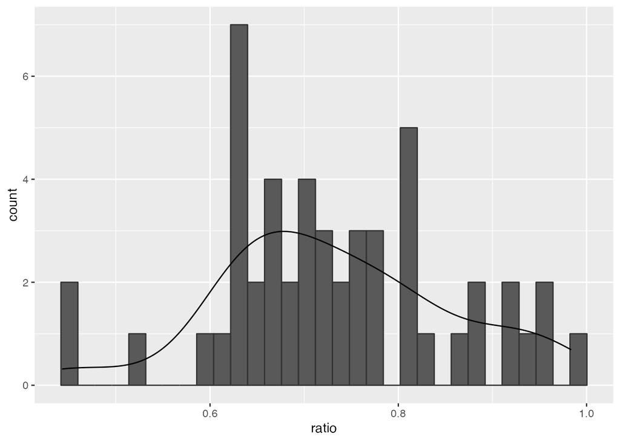

```r
d_person <- tapply(d2$Y, d2$PersonID, mean)
bw <- (max(d_person)-min(d_person))/30
ggplot(data = data.frame(X = d_person), aes(X)) +
  geom_histogram(color = 'grey20', binwidth = bw) +
  geom_line(aes(y = after_stat(count)*bw), stat = 'density') +
  labs(x = 'ratio', y = 'count')
```

データから計算できる科目ごとの出席率の分布は下記の通り。この分布をみることで、科目差を確認できる。

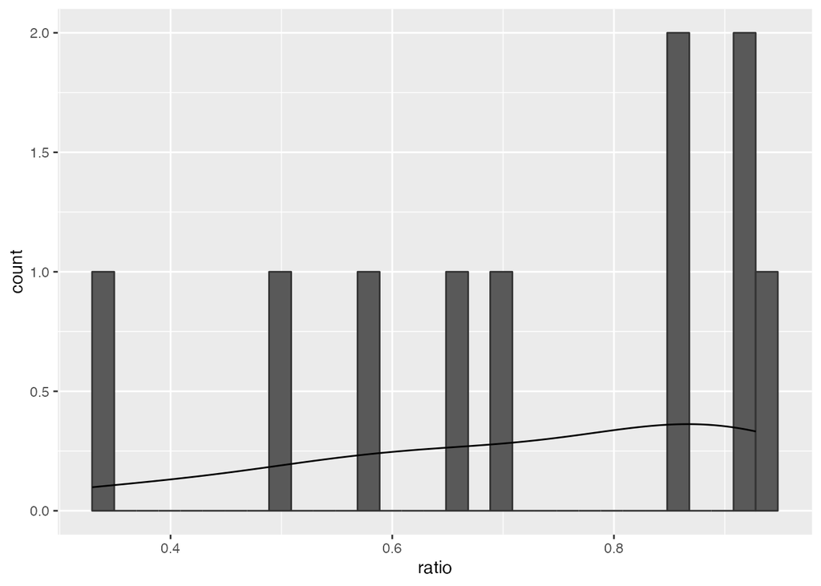

```r
d_course <- tapply(d2$Y, d2$CourseID, mean)
bw <- (max(d_course)-min(d_course))/30
ggplot(data = data.frame(X = d_course), aes(X)) +
  geom_histogram(color = 'grey20', binwidth = bw) +
  geom_line(aes(y = after_stat(count)*bw), stat = 'density') +
  labs(x = 'ratio', y = 'count')
```

## 参考文献および参考資料

- [StanとRでベイズ統計モデリング](https://www.kyoritsu-pub.co.jp/bookdetail/9784320112421)
- [StanとRでベイズ統計モデリング サポートページ](https://github.com/MatsuuraKentaro/RStanBook)
- [Stan Reference Manual](https://mc-stan.org/docs/reference-manual/index.html)